# Analyse de données d’échange – b) Les modèles à blocs stochastiques

11 et 12 Juin 2018

## Modèle d’Erdös-Rényi

```r
G1 <- igraph::sample_gnp(10, 0.1)
G2 <- igraph::sample_gnp(10, 0.9)
G3 <- igraph::sample_gnp(100, .02)
```

Tous les noeuds ont même probabilité de connexion.

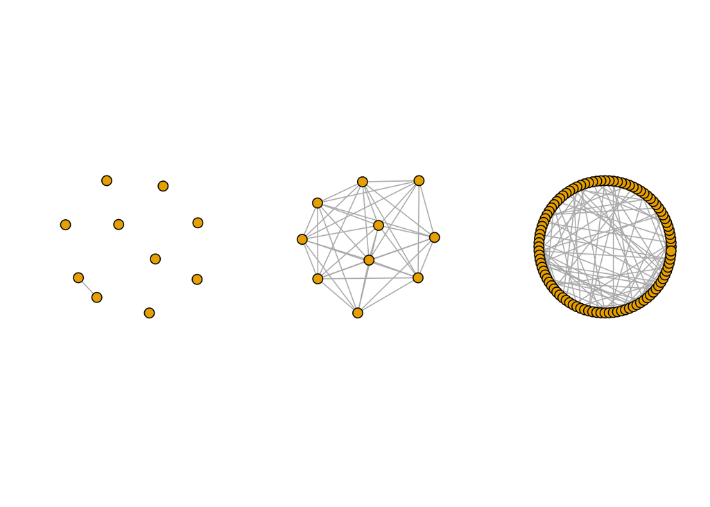

```r
par(mfrow=c(1,3))
plot(G1, vertex.label=NA)
plot(G2, vertex.label=NA)
plot(G3, vertex.label=NA, layout=layout.circle)
```

```r
# nombre moyen de noeuds sur un chemin
average.path.length(G3)
```

```
## [1] 5.917774
```

```r
# nombre de noeuds sur le plus long chemin
diameter(G3)
```

```
## [1] 15
```

```r
# coefficient de clustering
transitivity(G3)
```

```
## [1] 0.01775148
```

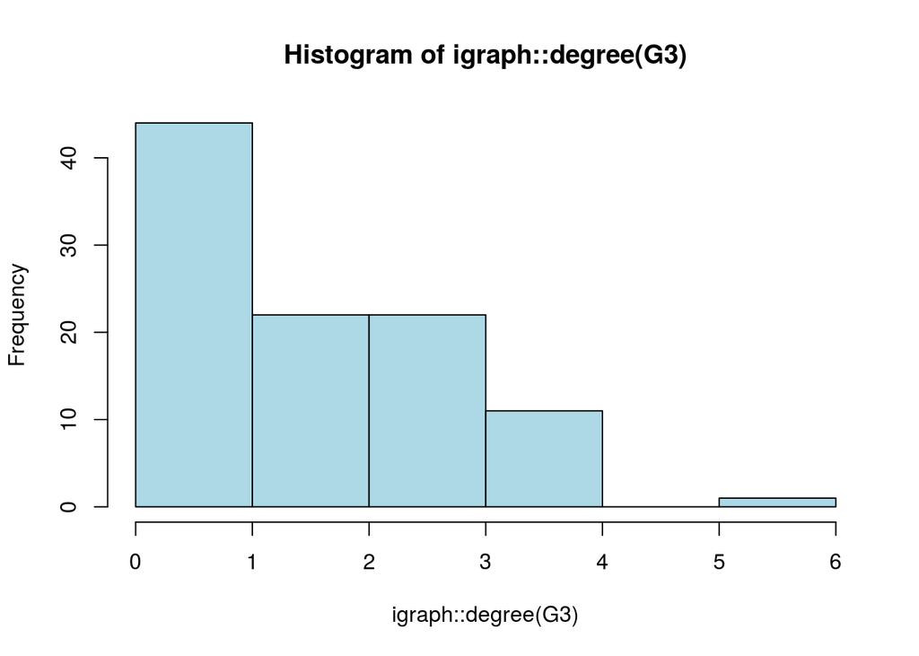

```r
hist(igraph::degree(G3), col="lightblue")
```

On remarque que $(i)$ les chemins le plus court et le plus long se constituent de relativement peu de noeuds, $(ii)$ le coefficient de clustering est assez faible et $(iii)$ la distribution des degrés est assez homogène.

## Modèle d’attachement préférentiel

```r
G1 <- igraph::sample_pa(20, 1, directed=FALSE)
G2 <- igraph::sample_pa(20, 5, directed=FALSE)
G3 <- igraph::sample_pa(200, directed=FALSE)
```

Les noeuds qui ont un fort degré ont de grandes chances d’être connectés : les riches s’enrichissent.

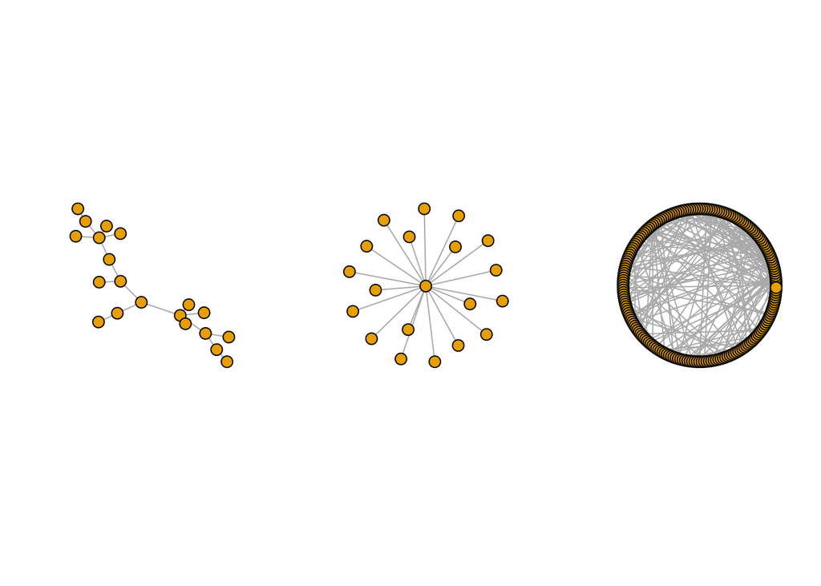

```r
par(mfrow=c(1,3))
plot(G1, vertex.label=NA)
plot(G2, vertex.label=NA)
plot(G3, vertex.label=NA, layout=layout.circle)
```

```r
average.path.length(G3)
```

```
## [1] 6.336332
```

```r
diameter(G3)
```

```
## [1] 14
```

```r
transitivity(G3)
```

```
## [1] 0
```

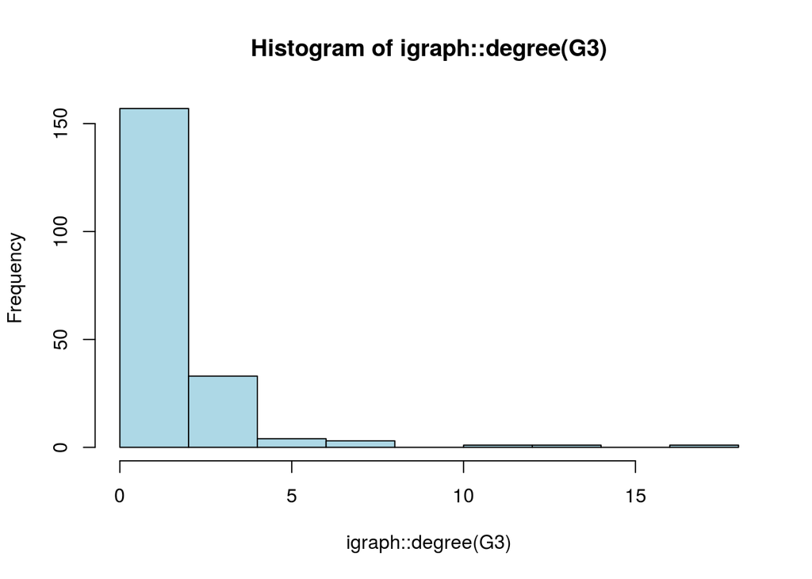

```r
hist(igraph::degree(G3), col="lightblue")
```

On remarque que $(i)$ les chemins le plus court et le plus long se constituent de relativement peu de noeuds, $(ii)$ le coefficient de clustering est assez faible et $(iii)$ la distribution des degrés est hétérogène et caractéristique d’une loi de puissance.

## Modèle exponentiel de graphe [ERGM]

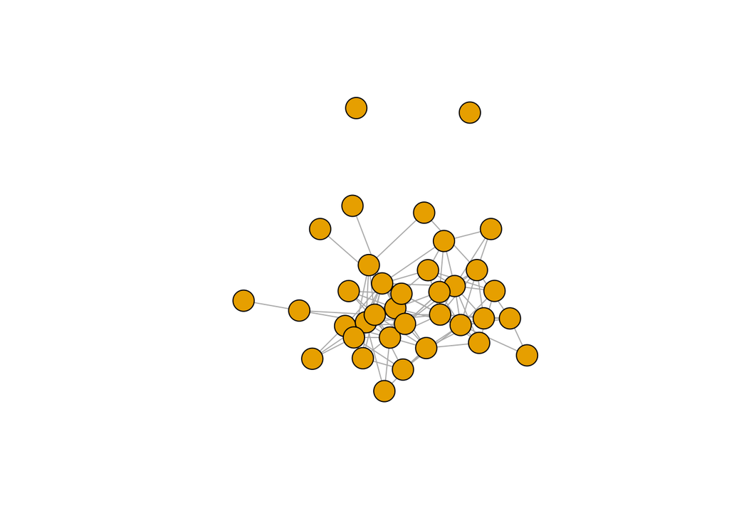

```r
data(lazega)
plot(lazega, vertex.label=NA)
```

```r
# un lien equivaut a une collaboration entre deux avocats
A <- get.adjacency(upgrade_graph(lazega))
lazega.s <- network::as.network(as.matrix(A), directed=FALSE)
my.ergm <- formula(lazega.s ~ edges + kstar(2) + kstar(3) + triangle)
summary.statistics(my.ergm)
```

```
##    edges   kstar2   kstar3 triangle
##      115      926     2681      120
```

La distribution des arêtes est due à la présence de différents motifs dans le réseau observé : arêtes, étoiles avec 2 ou 3 arêtes et triangles.

## Modèle à blocs stochastiques [SBM]

Dans un SBM, toute paire de noeuds a une probabilité de connexion induite par un caractère spécifique à chacun des noeuds : le groupe d’appartenance.

### Exemples de topologie

#### Réseau en étoile

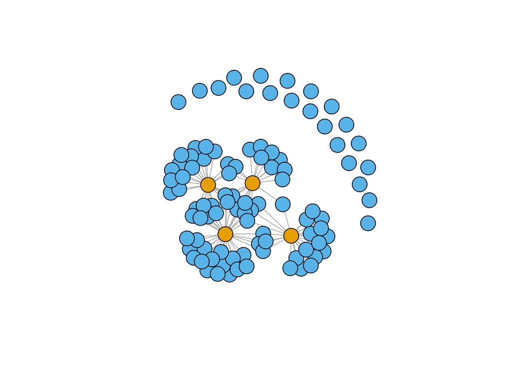

```r
pi <- matrix(c(0.05,0.3,0.3,0),2,2)
star <- igraph::sample_sbm(100, pi, c(4, 96))
plot(star, vertex.label=NA, vertex.color = rep(1:2,c(4,96)))
```

#### Réseau de communauté

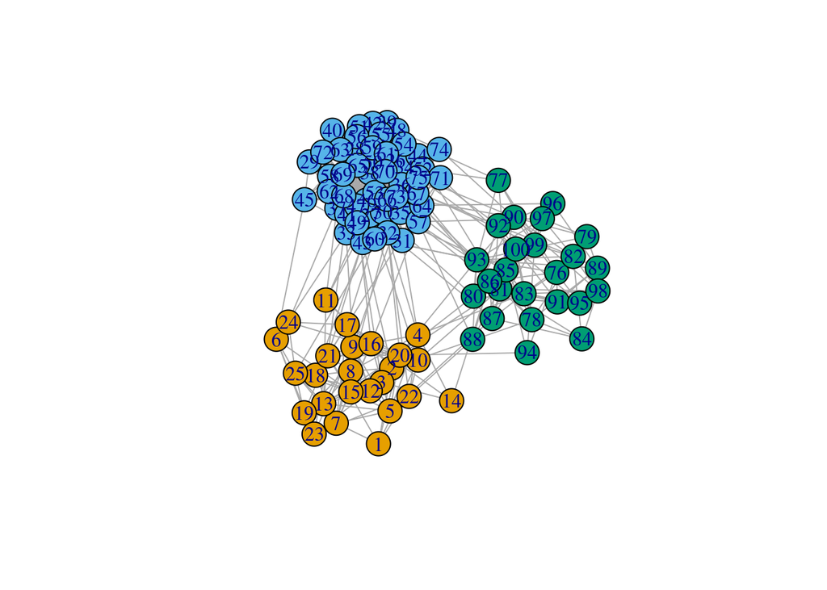

```r
pi <- matrix(c(0.3,0.02,0.02,0.02,0.3,0.02,0.02,0.02,0.3),3,3)
communities <- igraph::sample_sbm(100, pi, c(25, 50, 25))
plot(communities, vertex.color = rep(1:3,c(25, 50, 25)))
```

### Estimation des paramètres du SBM

#### Exemple du réseau de communautés

```r
# matrice d'adjacence
communities=as.matrix(get.adjacency(communities,type="both"))

my_model <- BM_bernoulli("SBM_sym",communities,verbosity=0,plotting='')
m=my_model$estimate()
```

```r
# nombre de groupes sélectionné avec vICL
Q=which.max(my_model$ICL)
Q
```

```
## [1] 3
```

```r
# probabilités de connexion entre groupes
my_model$model_parameters[Q]
```

```
## [[1]]
## [[1]]$pi
##            [,1]       [,2]       [,3]
## [1,] 0.32427538 0.01992475 0.02072240
## [2,] 0.01992475 0.28499617 0.01653587
## [3,] 0.02072240 0.01653587 0.28831205
##
## [[1]]$n_parameters
## [1] 6
```

```r
# probabilités a priori d'appartenance aux groupes
alpha=colSums(my_model$memberships[[Q]]$Z)/100
alpha
```

```
## [1] 0.4995005 0.2502498 0.2502498
```

```r
# probabilités a posteriori d'appartenance de chacun des noeuds aux groupes
head(my_model$memberships[[Q]]$Z)
```

```
##             [,1]     [,2]        [,3]
## [1,] 0.000999001 0.998002 0.000999001
## [2,] 0.000999001 0.998002 0.000999001
## [3,] 0.000999001 0.998002 0.000999001
## [4,] 0.000999001 0.998002 0.000999001
## [5,] 0.000999001 0.998002 0.000999001
## [6,] 0.000999001 0.998002 0.000999001
```

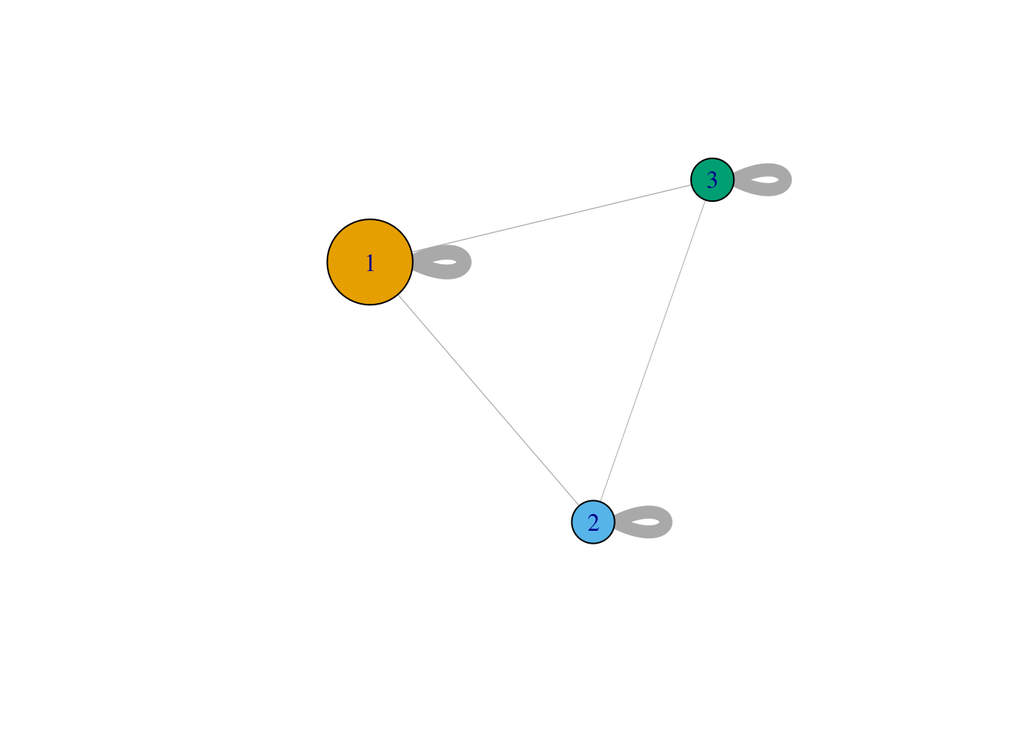

```r
# graphe des groupes
piS=my_model$model_parameters[[Q]]$pi
G = graph_from_adjacency_matrix(piS, mode = c("undirected"), weighted = TRUE, diag = TRUE)
plot.igraph(G,vertex.size=alpha*100,edge.width=abs(E(G)$weight*30),vertex.color=1:Q)
```

Le critère de sélection de modèle vICL donne un nombre de groupes égal à 3. On retrouve bien les probabilités de connexion entre groupes ($0.3$ et $0.02$), ainsi que les probabilités d’appartenance des noeuds aux groupes ($0.25$, $0.25$ et $0.5$).

#### Exemple du réseau des facultés anglaises

```r
# importation des donnees
load("UKfaculty_adj_cov.Rdata")

# extraction matrice d'adjacence
Net=as.matrix(UKfaculty_adj_cov$Net)
dim(Net)
```

```
## [1] 81 81
```

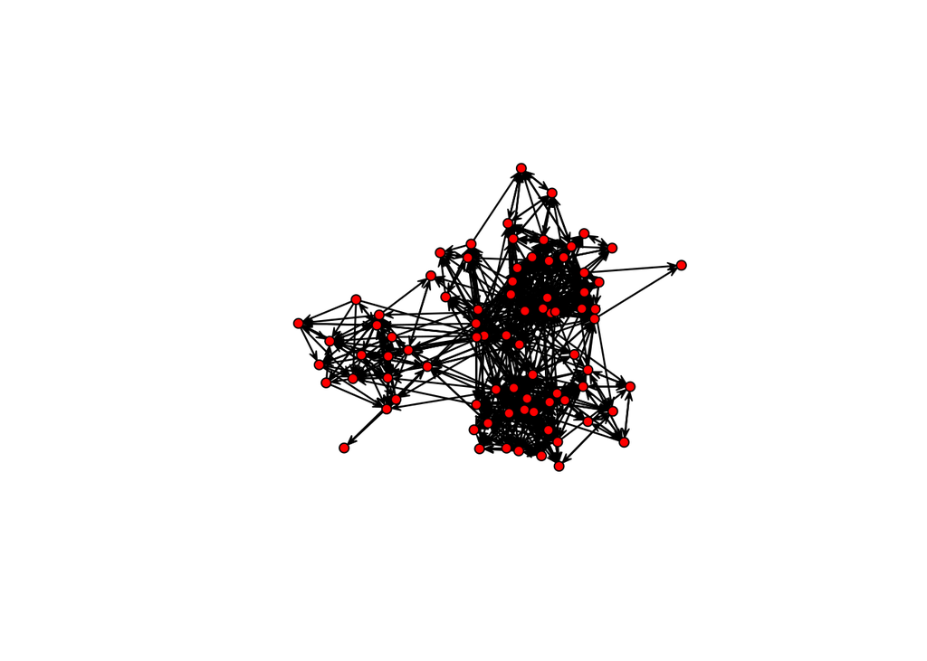

```r
gplot(Net)
```

```r
# densite du graphe
n=dim(Net)[2]
sum(Net)/(n*(n-1))
```

```
## [1] 0.1260802
```

```r
sbm.faculty <- BM_bernoulli("SBM",Net,verbosity=0,plotting='')
m=sbm.faculty$estimate()
```

```r
# nombre de groupes sélectionné
Q=which.max(sbm.faculty$ICL)
Q
```

```
## [1] 6
```

```r
# probabilités de connexion entre groupes
sbm.faculty$model_parameters[Q]
```

```
## [[1]]
## [[1]]$pi
##              [,1]         [,2]         [,3]       [,4]       [,5]
## [1,] 0.2437593236 0.0107926478 0.0009252367 0.12505332 0.02078907
## [2,] 0.0011205008 0.1715079970 0.0009121441 0.03542920 0.26653704
## [3,] 0.0009619842 0.0009676469 0.2815959348 0.07001797 0.01081655
## [4,] 0.4627811903 0.1673323005 0.1792719898 0.87847879 0.59334530
## [5,] 0.0151787223 0.3505033767 0.0291877198 0.16821436 0.77027214
## [6,] 0.0926845099 0.0120013959 0.0071893030 0.36029315 0.03784999
##            [,6]
## [1,] 0.08669446
## [2,] 0.02259791
## [3,] 0.01312155
## [4,] 0.65431845
## [5,] 0.03801117
## [6,] 0.48936570
##
## [[1]]$n_parameters
## [1] 36
```

```r
# probabilités a priori d'appartenance aux groupes
alpha=colSums(sbm.faculty$memberships[[Q]]$Z)/n
alpha
```

```
## [1] 0.16675228 0.18478202 0.22191054 0.05024724 0.14771276 0.22859516
```

```r
# probabilités a posteriori d'appartenance de chacun des noeuds aux groupes
head(sbm.faculty$memberships[[Q]]$Z)
```

```
##             [,1]        [,2]        [,3]        [,4]        [,5]
## [1,] 0.001228501 0.001228501 0.993857494 0.001228501 0.001228501
## [2,] 0.001228501 0.001228501 0.001228501 0.001228501 0.001228501
## [3,] 0.001228501 0.001228501 0.993857494 0.001228501 0.001228501
## [4,] 0.001228501 0.001228501 0.993857494 0.001228501 0.001228501
## [5,] 0.001228501 0.001228501 0.001228501 0.001228501 0.993857494
## [6,] 0.001228501 0.993857494 0.001228501 0.001228501 0.001228501
##             [,6]
## [1,] 0.001228501
## [2,] 0.993857494
## [3,] 0.001228501
## [4,] 0.001228501
## [5,] 0.001228501
## [6,] 0.001228501
```

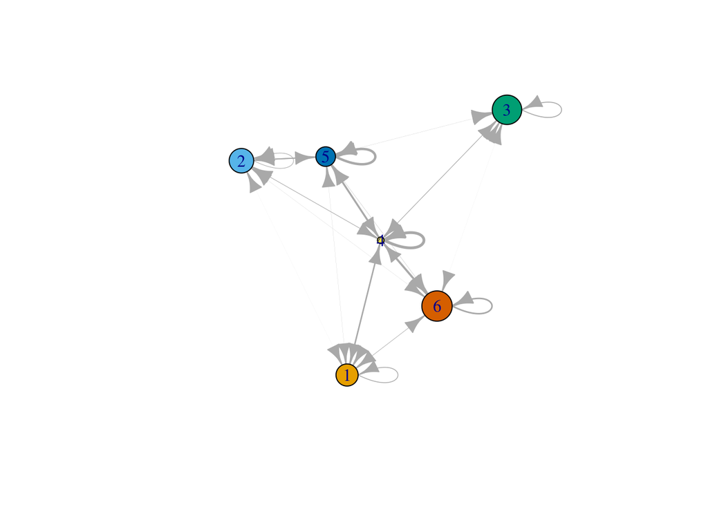

```r
# graphe des groupes
piS=sbm.faculty$model_parameters[[Q]]$pi
G = graph_from_adjacency_matrix(piS, mode = c("directed"), weighted = TRUE, diag = TRUE)
plot.igraph(G,vertex.size=alpha*100,edge.width=abs(E(G)$weight*3),vertex.color=1:Q)
```

### Estimation des paramètres du SBM avec covariables

La présence d’une arête dépend de l’appartenance de chaque noeud à un groupe ainsi que des covariables qui portent sur cette arête. La structure de groupe dépend alors d’informations autres à ces covariables.

Ici nous avons 4 covariables, une pour chaque université d’appartenance. Elles valent 1 si 2 individus sont dans la même université et 0 sinon.

```r
EdgeCovar=UKfaculty_adj_cov$EdgeCovar

# choix des covariables
listVar=list(EdgeCovar[,,1],EdgeCovar[,,2],EdgeCovar[,,3],EdgeCovar[,,4])

sbm.cov.faculty <- BM_bernoulli_covariates_fast("SBM",Net,listVar,verbosity=0,plotting='')
sbm.cov.faculty$estimate()
```

```r
# nombre de groupes sélectionné
Q=which.max(sbm.cov.faculty$ICL)
Q
```

```
## [1] 4
```

```r
# probabilités de connexion entre groupes et coefficient de regresseion
sbm.cov.faculty$model_parameters[Q]
```

```
## [[1]]
## [[1]]$n_parameters
## [1] 20
##
## [[1]]$m
##            [,1]       [,2]       [,3]       [,4]
## [1,]  3.7995735 -0.5383057  0.7438925  2.0180371
## [2,] -1.0749544  2.4395988 -1.9597593 -1.9440823
## [3,] -1.8605415 -3.8092872 -1.8706949 -1.7273005
## [4,]  0.2041624 -1.9068102 -0.7599070  0.1534652
##
## [[1]]$beta
##            [,1]
## [1,] -1.0347646
## [2,] -1.9038617
## [3,] -2.0131859
## [4,] -0.4077501
```

```r
# probabilités a priori d'appartenance aux groupes
alpha=colSums(sbm.cov.faculty$memberships[[Q]]$Z)/n
alpha
```

```
## [1] 0.07073902 0.07679833 0.40231682 0.45014582
```

```r
# probabilités a posteriori d'appartenance de chacun des noeuds aux groupes
head(sbm.cov.faculty$memberships[[Q]]$Z)
```

```
##             [,1]        [,2]        [,3]        [,4]
## [1,] 0.001233046 0.007881744 0.431306528 0.559578683
## [2,] 0.001231527 0.001231527 0.001231527 0.996305419
## [3,] 0.001233046 0.008215432 0.957411888 0.033139635
## [4,] 0.001231570 0.001231570 0.006700466 0.990836393
## [5,] 0.996305419 0.001231527 0.001231527 0.001231527
## [6,] 0.001233025 0.001233025 0.158632438 0.838901511
```

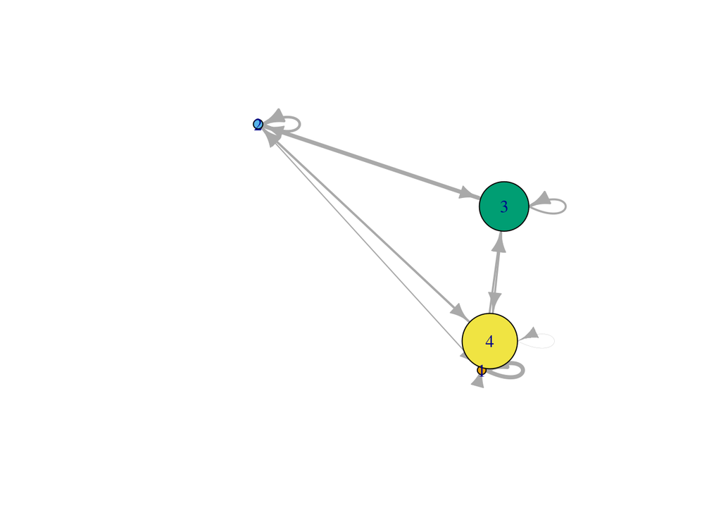

```r
piS=sbm.cov.faculty$model_parameters[[Q]]$m
G = graph_from_adjacency_matrix(piS, mode = c("directed"), weighted = TRUE, diag = TRUE)
plot.igraph(G,vertex.size=alpha*100,edge.width=abs(E(G)$weight),vertex.color=1:Q)
```

On trouve moins de groupes, 4 au lieu de 6, ce qui veut dire que l’on a pris en compte les covariables mais qu’il reste d’autres facteurs ici non identifiés qui engendrent une structure.